# Data Mining Capstone Project Report

Olga Shpakova

2023-04-27

## Introduction

This project report is written as part of the introductory course in data mining at the University of Lucerne. Its focus is on data collection, rather than data analysis or answering a specific research question.

## Zenodo Scraping Project

This project is concerned with exploration and visualization of social science communities and metadata of their publications on Zenodo using R. Zenodo is an online storage service that can be used for scientific datasets, but also for science-related software, publications, reports, presentations, videos, etc. The service is funded by the European Commission. Zenodo integrates the GitHub repository service to make source code stored on GitHub citable. Zenodo’s own source code is also available on GitHub. Publications are given a citable DOI. There is ORCID integration, user statistics, and various licensing options. The website is maintained by the OpenAIRE consortium and CERN. Zenodo was launched in 2013. As of March 2023, it contained over three million documents and more than one petabyte of data. Zenodo provides the platform **11414** communities created and curated by Zenodo users (Status 04/24/2023). This fact makes the exploration of Zenodo with computational automated methods - here specifically with R - interesting. For more information regarding Zenodo see https://zenodo.org/.

The University of Lucerne also uses Zenodo and is committed to ensuring that its researchers publish their scientific publications in open access whenever possible. One of the reasons for this is to make the research results generated here available to other researchers and the public without restriction, in line with the principle of “knowledge for all”. With the channel in the campus-wide “Lucerne Open Repository” (LORY), the university offers a platform on which university members can publish their publications permanently and securely (as the Luzerner Zeitung writes: [link](https://www.luzerner-rundschau.ch/stadt/detail/article/open-access-preis-00191283/)).

## Data Collection

To retrieve the data from Zenodo, the API of Zenodo was used and the following strategy was applied (Munzert et al. 2015: 221-222):

1. Information identification (see Zenodo Scraping Project part)
2. Choice of strategy
3. Data retrieval
4. Information extraction
5. Data preparation
6. Data validation
7. Debugging and maintenance
8. Generalization

### Communities Scraping

To retrieve data from the Zenodo repository, several R packages are used, including “httr”, “tidyverse”, and “zen4R”. The first step involve creating an instance of the Zenodo manager to interact with the Zenodo API and perform desired actions. In order to search for publications relevant to and belonging to the social science field from the large number of publications, the keyword search is considered. As keywords are not entered reliably by Zenodo users, this approach had to be discarded. The Zenodo API did not offer its own function to get all communities, so “zen4R” package is used.

The second step utilize the “getCommunities()” method of the Zenodo manager to retrieve a list of all the communities on the Zenodo repository. This results in 10000 communities described by several variables, including ID, title, and description. The final step is to filter the communities based on selected keywords to only include communities related to social science. To achieve this, a custom function called “keyword_detect” is implemented to search for specific keywords within a dataset, which returned a logical vector with “TRUE” values for rows that contain any of the keywords. This step allows for a flexible and customizable way to filter and subset the dataset based on specific keyword criteria.

In the first filtering step, a list of communities is created to only include those that contain at least one of the strings “social”, “psych” or “socio” in their title or description, resulting in 734 communities. In the second filtering step, a secondary filter is applied to narrow the selection to only include communities related to the specific fields of sociology and psychology, resulting in 78 communities. This ensure that the final analysis focuses on the most relevant communities for the research interest at hand. A look at the dataset, however, showed that many medical communities were among the final communities despite the filtering.There was thus the difficulty of finding only relevant communities. The filtering can certainly be improved.

### Publications Scraping

The second part of the data collection process involves requesting publication data from the Zenodo API for selected communities. The code sets two variables, “status” and “size”, which control the API query parameters. The parameter “status” is set to “published”, indicating that the query should only return published records, while “size” is set to “200”, indicating that up to 200 records per request should be returned.

An empty dataframe is created in this step, which will be used to store the metadata for publications meeting the specified criteria (title, journal, authors, date, description, keywords, and community) with predefined columns. This enables the code to fill the dataframe with retrieved data in a structured way.

A loop is used to iterate over the IDs of the communities filtered in the previous step. For each community, the code constructs an endpoint URL for the Zenodo API using the string formatting from the “glue” library. The URL includes the specified parameters “status”, “size” and “page” as well as the current community ID. The code then sends a GET request to the API and extracts the parsed data from the response using the “content” function. The resulting “records” object is a list of metadata from the Zenodo API, including titles, journals, dates, descriptions, keywords, and other relevant information. The relevant information is then added to the dataframe. The page number is increased by one in the while loop until the number of records returned is smaller than the specified page size of 200 which indicates that there are no more publications to scrape.

The authors and authorships that were initially included in the dataset were later removed. As the publication retrieval can take up to several minutes, a progress bar from the “progress” library is used to monitor the progress.

After too many requests to the API with a guest account (error code 429), Zenodo blocks access. To resolve this, a Sys.sleep statement is used to reduce the request frequency to not exceed the allowed 60 requests per minute.

## Data Analysis and Results

For analysis of data several libraries were used, including “tidyverse”, “wordcloud2”, “tm”, “readr”, “dplyr”, “viridis” and “extrafont”. The analysis was directed to the Word clouds generated from the descriptions of texts to determine which words appear most frequently and to elicited the most popular topics among the communities. For this purpose corpus object was created from the “description” column of the “publications_df” data frame using the “VectorSource” and “Corpus” functions from the “tm” package. Because the description column contained text in html format, it was cleaned up using regular expressions and “tm” package.

In this cleaning step, a Term Document Matrix (TDM) object war created from the Zenodo corpus containing the word frequencies for each term in the corpus. The resulting TDM was then converted into a matrix, and a vector of the total frequency of each word was created and data frame with two columns: one column contains the unique words from the Zenodo corpus, and the other contains the corresponding frequency of each word. Rows containing strings with less than two characters or “don’” were then manually removed.

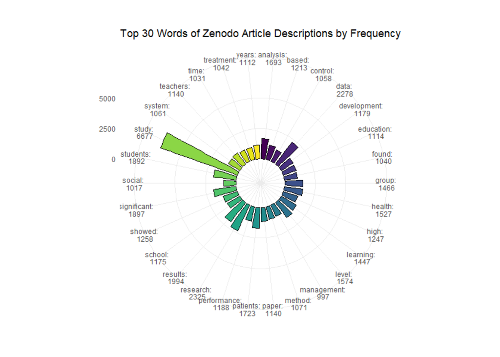

Figure 1: Word Frequency

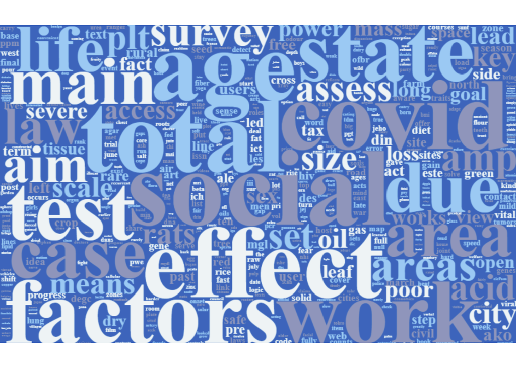

Figure 2: Word Cloud

## Conclusion

As an open-source repository, Zenodo contains many publications that are not regularly managed and organized. This fact makes scraping and analyzing Zenodo publications cumbersome. The aim of this project was to extract the publications from the field of social sciences for further possible analysis. It needs further manipulation and manual inspection from the dataset to get good starting point for analysis.

## References

Munzert et al. (2015): Automated Data Collection with R. URL: [link](http://repo.darmajaya.ac.id/3825/1/Automated%20Data%20Collection%20with%20R_%20A%20Practical%20Guide%20to%20Web%20Scraping%20and%20Text%20Mining%20%28%20PDFDrive%20%29.pdf) (last access: 26.04.2023)

Unkel, Julian (2020): Computational Methods in der politischen Kommunikationsforschung. Methodische Vertiefung: Computational Methods mit R und RStudio. URL: [link](https://bookdown.org/joone/ComputationalMethods/) (last access: 26.04.2023)

Zenodo (n. d.): Zenodo Developers. URL: [link](https://developers.zenodo.org/) (last access: 26.04.2023)